# *hyperSpec* Plotting Functions

Claudia Beleites

chemometrie@beleites.de

2019-12-28

# Suggested Packages and Setup

> **Reproducing the examples in this vignette.**  
> All spectra used in this manual are installed automatically with package **hyperSpec**.

```r
library(hyperSpec)
library(latticeExtra)
library(deldir)
library(rgl)
library(ggplot2)

par(mar = c(4.1, 4.1, 1, .6))

set.seed(2020)
```

Besides, package **tripack**, and package **latticist** are mentioned, but not used in this vignette.

# Preliminary Calculations

For some plots of the `chondro` dataset, the pre-processed spectra and their cluster averages $\pm$ one standard deviation are more suitable:

```r
chondro <- hyperSpec::chondro

chondro.preproc <- chondro - spc.fit.poly.below(chondro)
chondro.preproc <- chondro.preproc / rowMeans(chondro)
chondro.preproc <- chondro.preproc - quantile(chondro.preproc, 0.05)

cluster.cols   <- c("dark blue", "orange", "#C02020")
cluster.meansd <- aggregate(chondro.preproc, chondro$clusters, mean_pm_sd)
cluster.means  <- aggregate(chondro.preproc, chondro$clusters, mean)
```

For details about the pre-processing, please refer to the example workflow in `vignette("chondro")`, or the help `?chondro`.

# 1 Predefined Functions

**`plot()`**

main switchyard for most plotting tasks. More details in section 2.

**`plotspc()`**

plots spectra. More details in sections 1.1, 2.1, and 3.

**`plotc()`**

calibration plot, time series, depth profile. More details in sections 1.3, 2.5, 2.6, 2.7, and 4.  
(`plotc()` is a package **lattice** function)

**`levelplot()`**

package **hyperSpec** has a method for package **lattice**[1] function `levelplot()`. More details in sections 1.4, and 5.

**`plotmat()`**

plots the spectra matrix. More details in sections 1.2, 2.8, and 6.

**`plotmap()`**

more specialized version of `levelplot()` for map or image plots. More details in sections 1.5, 2.9, and 7. (`plotmap()` is a package **lattice** function)

**`plotvoronoi()`**

more specialized version of `plotmap()` that produces Voronoi tesselations.  
More details in sections 1.6, and 2.10.  
(`plotvoronoi()` is a package **lattice** function)

> **NOTE.** Functions `plotmap()`, `plotvoronoi()`, and `levelplot()` are package **lattice** functions. Therefore, in loops, functions, R Markdown chunks, etc. lattice objects need to be printed explicitly by, e.g., `print(plotmap(object))` ([R FAQ: Why do lattice/trellis graphics not work?](http://cran.r-project.org/doc/FAQ/R-FAQ.html#Why-do-lattice_002ftrellis-graphics-not-work_003f)).

## 1.1 Function `plotspc()`

Function `plotspc()` plots the spectra (Fig. 1.1), i.e., the intensities (`$spc`) over the wavelengths (`@wavelength`).

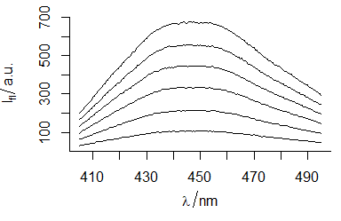

Figure 1.1: Spectra in dataset `flu`.

```r
plotspc(flu)
```

## 1.2 Function `plotmat()`

Function `plotmat()` plots the spectra, i.e., the colour coded intensities (`$spc`) over the wavelengths (`@wavelength`) and the row number (Fig. 1.2).

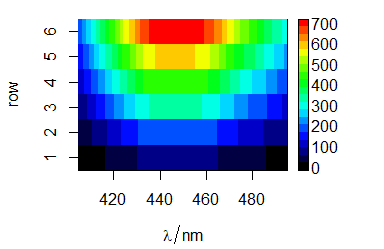

Figure 1.2: Matrix of spectra: the colour coded intensities over the wavelengths and the row number.

```r
plotmat(flu)
```

## 1.3 Function `plotc()`

Function `plotc()` plots an intensity over a single other data column, e.g., concentration (calibration plot, e.g., Fig. 1.3), depth (depth profile plot), or time (time series plot).

```
#> Warning in plotc(flu): Intensity at first wavelengh only is used.
```

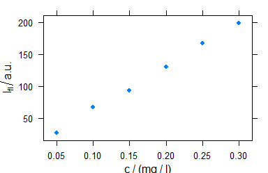

Figure 1.3: Calibration plot: an intensity over concentration.

```r
plotc(flu)
```

> The following warning is expected: `Intensity at first wavelengh only is used.`

## 1.4 Function `levelplot()`

```
#> Warning in .local(x, data, ...): Only first wavelength is used for plotting
```

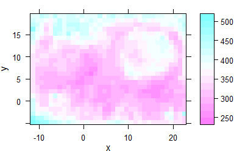

Figure 1.4: False colour map (1).

```r
levelplot(spc ~ x * y, chondro, aspect = "iso")
```

> The following warning is expected: `Only first wavelength is used for plotting`.

## 1.5 Function `plotmap()`

Function `plotmap()` is a specialized version of `levelplot()`. It uses a single value (e.g., average intensity or cluster membership) over two data columns (default are `$x` and `$y`) to plot a false colour map (Fig. 1.5).

```r
plotmap(chondro)
```

[output not shown]

## 1.6 Function `plotvoronoi()`

Function `plotvoronoi()` is a special version of `plotmap()` that produces Voronoi diagram of the `hyperSpec` object (Fig. 1.6).

[output not shown]

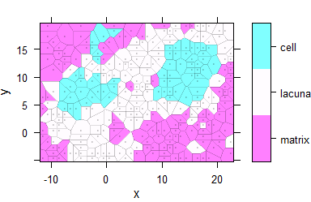

Figure 1.6: Voronoi diagram: an example with `chondro` dataset.

```r
plotvoronoi(sample(chondro, 300), clusters ~ x * y)
```

# 2 Arguments for `plot()`

The **hyperSpec**’s `plot()` method uses its second argument to determine which of the specialized plots to produce. This allows some handy abbreviations. All further arguments are handed over to the function actually producing the plot.

## 2.1 Argument `"spc"`

Command `plot(x, "spc")` is equivalent to `plotspc(flu)` (Fig. 2.1).

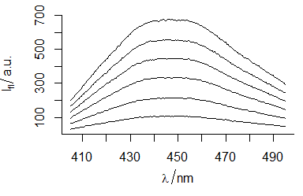

Figure 2.1: All spectra of dataset `flu`.

```r
plot(flu, "spc")
```

## 2.2 Argument `"spcmeansd"`

Command `plot(x, "spcmeansd")` plots mean spectrum $\pm$ 1 standard deviation (Fig. 2.2).

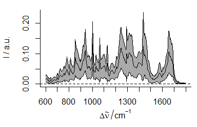

Figure 2.2: Summary spectra: mean $\pm$ one standard deviation at each wavelength (wavenumber).

```r
plot(chondro.preproc, "spcmeansd")
```

## 2.3 Argument `"spcprctile"`

Code `plot(x, "spcprctile")` plots median, 16<sup>th</sup> and 84<sup>th</sup> percentile for each wavelength (Fig. 2.3). For Gaussian distributed data, 16<sup>th</sup>, 50<sup>th</sup> and 84<sup>th</sup> percentile are equal to mean $\pm$ standard deviation. Spectroscopic data frequently are not Gaussian distributed. The percentiles give a better idea of the true distribution. They are also less sensitive to outliers.

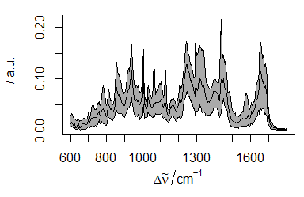

Figure 2.3: Summary spectra: median, 16<sup>th</sup> and 84<sup>th</sup> percentiles at each wavelength (wavenumber).

```r
plot(chondro.preproc, "spcprctile")
```

## 2.4 Argument `"spcprctl5"`

The code `plot(x, "spcprctl5")` is like `"spcprctile"` plus 5<sup>th</sup> and 95<sup>th</sup> percentile (Fig. 2.4).

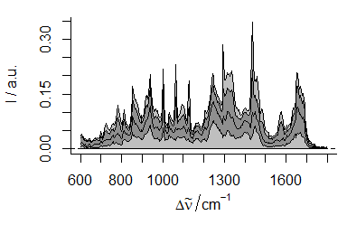

Figure 2.4: Summary spectra: median, 5<sup>th</sup>, 16<sup>th</sup>, 84<sup>th</sup>, 95<sup>th</sup> percentiles at each wavelength (wavenumber).

```r
plot(chondro.preproc, "spcprctl5")
```

## 2.5 Argument `"c"`

Command `plot(x, "c")` is equivalent to `plotc(flu)` (Fig. 2.5).

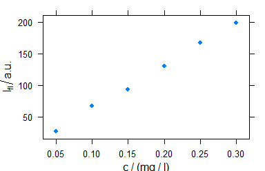

Figure 2.5: Calibration plot: spectra intensities over concentration.

```r
plot(flu, "c")
```

## 2.6 Argument `"ts"`

Function `plot(x, "ts")` plots a time series plot and is equivalent to `plotc(laser, spc ~ t)` (Fig. 2.6).

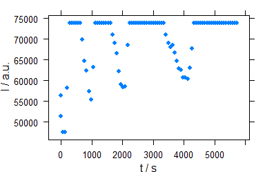

Figure 2.6: Time series plot: spectra intensities over time.

```r
plot(laser[, , 405], "ts")
```

## 2.7 Argument `"depth"`

Code `plot(x, "depth")` plots a depth profile plot and is the same as `plotc(laser, spc ~ z)` (Fig. 2.7).

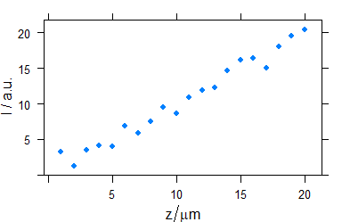

Figure 2.7: Depth profile plot.

```r
depth.profile <- new("hyperSpec",
  spc    = as.matrix(rnorm(20) + 1:20),
  data   = data.frame(z = 1:20),
  labels = list(
    spc = "I / a.u.",
    z   = expression(`/`(z, mu * m)),
    .wavelength = expression(lambda)
  )
)

plot(depth.profile, "depth")
```

## 2.8 Argument `"mat"`

Code `plot(x, "mat")` plots the spectra matrix (Fig. 2.8).

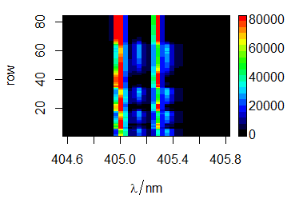

Figure 2.8: Spectra matrix.

```r
plot(laser, "mat")
```

The code is equivalent to:

```r
plotmat(laser)
```

A **lattice** alternative is:

```r
levelplot(spc ~ .wavelength * .row, data = laser)
```

## 2.9 Argument `"map"`

Code `plot(x, "map")` is equivalent to `plotmap(chondro)` (Fig. 2.9).

```r
plot(chondro, "map")
```

[output not shown]

## 2.10 Argument `"voronoi"`

Use `plot(x, "voronoi")` for a Voronoi plot (Fig. 2.10).

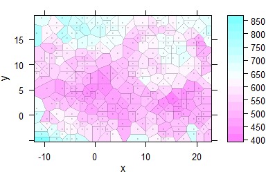

Figure 2.10: Voronoi plot: alternative R syntax.

```r
plot(sample(chondro, 300), "voronoi")
```

See `?plotvoronoi` and `?latticeExtra::panel.voronoi`.

# 3 Customized Plots of Spectra: `plotspc()`

Function `plotspc()` offers a variety of parameters for customized plots.

## 3.1 Plot Particular Wavelength Range

If only one wavelength range is needed (Fig. 3.1), the extract command is handiest.

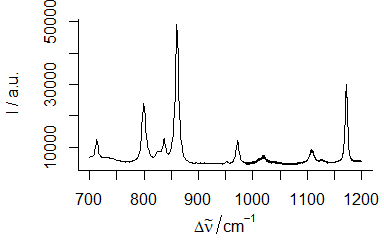

Figure 3.1: Plot of wavelength (wavenumber) range from 700 to 1200 $cm^{-1}.$

```r
plotspc(paracetamol[, , 700 ~ 1200])
```

Numbers connected with the tilde (`~`) are interpreted as having the same units as the wavelengths. If `wl.range` already contains indices use `wl.index = TRUE`. For more details refer to `vignette("hyperspec", package = "hyperSpec")`.

## 3.2 Plot Several Wavelength Ranges

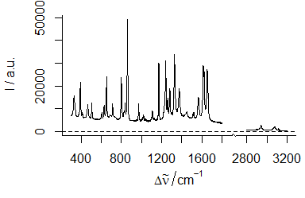

Figure 3.2: Plot of several wavelength (wavenumber) ranges.

```r
plotspc(paracetamol,
  wl.range = c(300 ~ 1800, 2800 ~ max),
  xoffset = 750
)
```

## 3.3 Plot with Reversed Abscissa

To create a plot with reversed abscissa (Fig. 3.3), use `wl.reverse = TRUE`

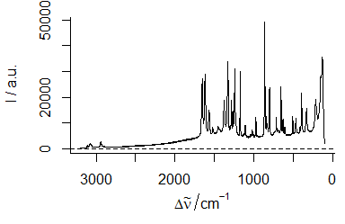

Figure 3.3: Plot with reversed/descending wavelength (wavenumber) range.

```r
plotspc(paracetamol, wl.reverse = TRUE)
```

## 3.4 Plot in Different Colours

To have different colours of spectra (Fig. 3.4), use `col = vector_of_colours`.

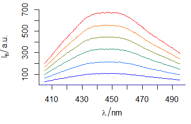

Figure 3.4: Spectra plotted in different colours.

```r
plotspc(flu, col = matlab.dark.palette(6))
```

## 3.5 Plot Dots Instead of Lines

To plot dots instead of lines (Fig. 3.5), use, e.g., `lines.args = list (pch = 20, type = "p")`

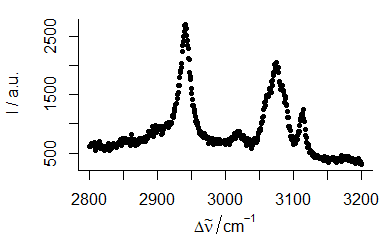

Figure 3.5: Spectrum with dots instead of lines.

```r
plotspc(paracetamol[, , 2800 ~ 3200],
  lines.args = list(pch = 20, type = "p")
)
```

## 3.6 Plot Mass Spectra

TO plot mass spectra (Fig. 3.6), use `lines.args = list(type = "h")`

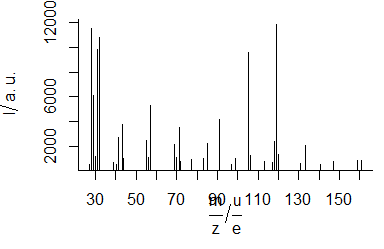

Figure 3.6: An example of mass spectrum.

```r
plot(barbiturates[[1]], lines.args = list(type = "h"))
```

## 3.7 Add More Spectra into an Existing Plot

To plot additional spectra onto an existing plot (Fig. 3.7), use `add = TRUE`

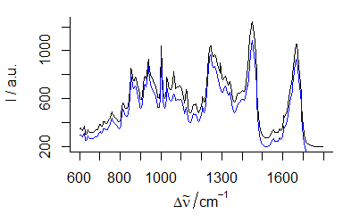

Figure 3.7: A spectrum added to an existing plot.

```r
plotspc(chondro[ 30, , ])
plotspc(chondro[300, , ], add = TRUE, col = "blue")
```

## 3.8 Plot Summary Characteristics

Argument `func` may be used to calculate summary characteristics before plotting. To plot, e.g., the standard deviation of the spectra, use `plotspc(..., func = sd)` (Fig. 3.8).

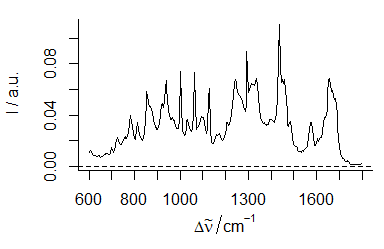

Figure 3.8: A spectrum of summary statistics calculated via `func` parameter. In the example, the standard deviation is used.

```r
plotspc(chondro.preproc, func = sd)
```

## 3.9 Plot Different Line at $I = 0$

To plot a different line at zero intensity $(I = 0)$, argument `zeroline` may be used (Fig. 3.9). Argument `zeroline` takes a list with parameters that are passed to function `abline()`, `NA` suppresses the line.

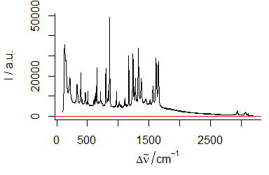

Figure 3.9: Spectrum with added zero-intensity line.

```r
plotspc(paracetamol,
  zeroline = list(col = "red")
)
```

## 3.10 Adding Annotations to a Spectra Plot

Function `plotspc()` uses base graphics. After plotting the spectra, more content may be added to the graphic by `abline()`, `lines()`, `points()`, etc. (Fig. 3.10).

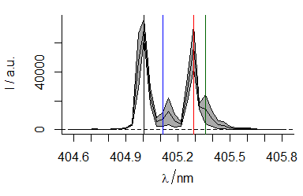

Figure 3.10: A summary spectrum with annotation lines.

```r
plot(laser, "spcmeansd")
abline(
  v = c(405.0063, 405.1121, 405.2885, 405.3591),
  col = c("black", "blue", "red", "darkgreen")
)
```

## 3.11 Stacked Spectra

### 3.11.1 Simple Stacking

To stack spectra, use `stacked = TRUE` (Fig. 3.11).

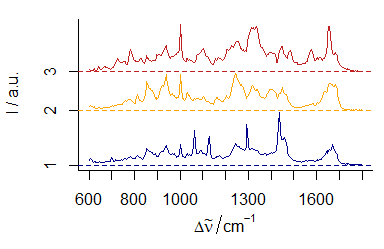

Figure 3.11: Stacked spectra of means.

```r
plotspc(cluster.means,
  col = cluster.cols,
  stacked = TRUE
)
```

### 3.11.2 Stacking Groups of Spectra

The spectra to be stacked can be grouped: `stacked = "factor"`. Alternatively, the name of an extra data column can be used for grouping (Fig. 3.12).

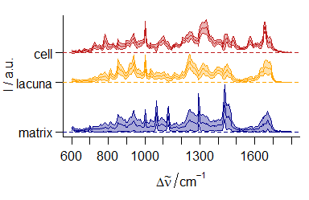

Figure 3.12: Stacked summary spectra (mean $\pm$ one standard deviation).

```r
op <- par(las = 1, mgp = c(3.1, .7, 0))

plot(cluster.meansd,
  stacked = ".aggregate",
  fill    = ".aggregate",
  col     = cluster.cols
)
```

### 3.11.3 Manually Giving `yoffset`

Stacking values can also be given manually as numeric values in `yoffset` (Fig. 3.13).

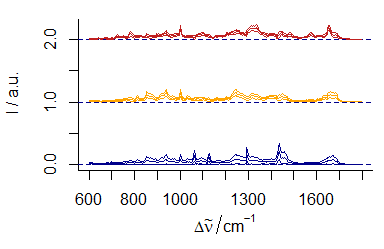

Figure 3.13: Stacked spectra with customized y offset.

```r
plotspc(cluster.meansd,
  yoffset = rep(0:2, each = 3),
  col = rep(cluster.cols, each = 3)
)
```

### 3.11.4 Dense Stacking

It is possible to obtain a denser stacking (Fig. 3.14).

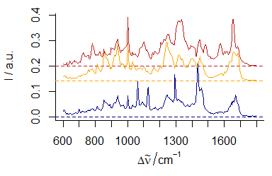

Figure 3.14: Dense-stacked spectra.

```r
yoffsets <- apply(cluster.means[[]], 2, diff)
yoffsets <- -apply(yoffsets, 1, min)
plot(cluster.means,
  yoffset = c(0, cumsum(yoffsets)),
  col = cluster.cols
)
```

### 3.11.5 Elaborate Example

Function `plotspc()` allows fine grained customization of almost all aspects of the plot (see example in Fig. 3.15). This is possible by giving arguments to the functions that actually perform the plotting `plot()` for setting up the plot area, `lines()` for the plotting of the lines, `axis()` for the axes, etc. The arguments for these functions should be given in lists as `plot.args`, `lines.args`, `axis.args`, etc.

[figure not shown]

Figure 3.15: An example of highly customized spectra.

```r
yoffset <- apply(chondro.preproc, 2, quantile, c(0.05, 0.95))
yoffset <- range(yoffset)
plot(chondro.preproc[1],
  plot.args = list(ylim = c(0, 2) * yoffset),
  lines.args = list(type = "n")
)
yoffset <- (0:1) * diff(yoffset)
for (i in 1:3) {
  plot(chondro.preproc, "spcprctl5",
    yoffset = yoffset[i],
    col = "gray", add = TRUE
  )
  plot(chondro.preproc[i],
    yoffset = yoffset[i],
    col = matlab.dark.palette(3) [i], add = TRUE,
    lines.args = list(lwd = 2)
  )
}
```

# 4 Calibration, (Depth) Profile, and Time Series Plots: `plotc()`

## 4.1 Intensities over Concentration

Spectra intensities of one wavelength can be plotted over the concentration for univariate calibration (Fig. 4.1).

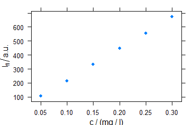

Figure 4.1: Intensities at 450 nm over concentration.

```r
plotc(flu[, , 450])
```

The default is to use the first intensity only.

## 4.2 Summary Intensities over Concentration

A function to compute a summary of the intensities before the drawing can be used via argument `func` (Fig. 4.2).

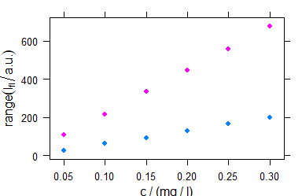

Figure 4.2: The summary (minimum and maximum) of intensities at each measured concentration.

```r
plotc(flu, func = range, groups = .wavelength)
```

If `func()` returns more than one value, the different results are accessible by `.wavelength`.

## 4.3 Conditioning: Plotting More Traces Separately

**Lattice** conditioning (operator `|`) can be used to plot more traces separately (Fig. 4.3).

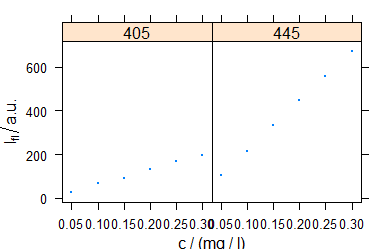

Figure 4.3: Conditioning: several calibration spectra on separate subplots.

```r
plotc(flu[, , c(405, 445)], spc ~ c | .wavelength,
  cex = .3, scales = list(alternating = c(1, 1))
)
```

## 4.4 Grouping: Plot More Traces in One Panel

Argument `groups` may be used as a grouping parameter to plot more traces in one panel (Fig. 4.4).

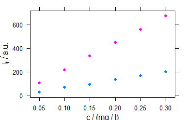

Figure 4.4: Grouping: several calibration spectra on one plot.

```r
plotc(flu[, , c(405, 445)], groups = .wavelength)
```

## 4.5 Changing Axis Labels (and Other Parameters)

Arguments of **lattice** function `xyplot()` can be given to `plotc()` (Fig. 4.5).

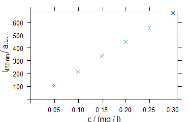

Figure 4.5: Modified axis labels and point characters.

```r
plotc(flu[, , 450],
  ylab = expression(I["450 nm"] / a.u.),
  xlim = range(0, flu$c + .01),
  ylim = range(0, flu$spc + 10),
  pch = 4
)
```

## 4.6 Adding Things to the Plot: Customized Panel Function

As `plotc()` uses the package **lattice** function `xyplot()`, additions to the plot must be made via the panel function (Fig. 4.6).

```r
panelcalibration <- function(x, y, ..., clim = range(x), level = .95) {
  panel.xyplot(x, y, ...)
  lm <- lm(y ~ x)
  panel.abline(coef(lm), ...)
  cx <- seq(clim[1], clim[2], length.out = 50)
  cy <- predict(lm, data.frame(x = cx),
    interval = "confidence",
    level = level
  )
  panel.lines(cx, cy[, 2], col = "gray")
  panel.lines(cx, cy[, 3], col = "gray")
}
```

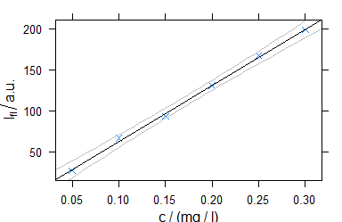

Figure 4.6: Plot that uses a customized paanel function.

```r
plotc(flu[, , 405],
  panel = panelcalibration,
  pch = 4, clim = c(0, 0.35), level = .99
)
```

## 4.7 Time Series and Other Plots of the Type “Intensity-over-Something”

Abscissae other than `c` may be specified by explicitly giving the model formula (Fig. 4.7).

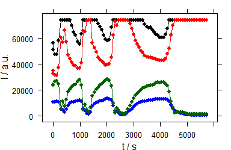

Figure 4.7: Plot with abscissae explicitly indicated by model formula.

```r
plotc(laser[, , c(405.0063, 405.1121, 405.2885, 405.3591)],
  spc ~ t,
  groups = .wavelength,
  type   = "b",
  col    = c("black", "blue", "red", "darkgreen")
)
```

# 5 Levelplot: `levelplot()`

Package **hyperSpec**’s function `levelplot()` can use two special column names:

- **.wavelength** for the wavelengths,
- **.row** for the row index (i.e., spectrum number) in the data.

Besides that, it behaves exactly like **lattice** `levelplot()`. Particularly, the data is given as the *second* argument (Fig. 5.1).

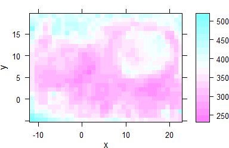

Figure 5.1: An example of a levelplot.

```r
levelplot(spc ~ x * y, data = chondro)
```

If the colour-coded value is a factor, the display is adjusted to this fact (Fig. 5.2).

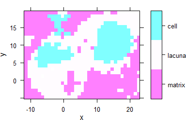

Figure 5.2: Levelplot when colour-coded value is a factor.

```r
levelplot(clusters ~ x * y, data = chondro)
```

# 6 Spectra Matrix: `plotmat()`

It is often useful to plot the spectra against an additional coordinate, e.g., the time for time series, the depth for depth profiles, etc. This can be done by `plot(object, "mat")`. The actual plotting is done by `image()`, but `levelplot()` can produce spectra matrix plots as well and these plots can be grouped or conditioned.

## 6.1 Different Palette

Argument `col` can be used to provide a different colour palette (Fig. 6.1).

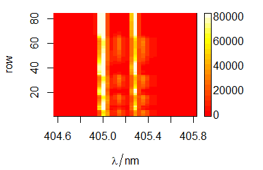

Figure 6.1: Spectra matrix with non-default palette.

```r
plot(laser, "mat", col = heat.colors(20))
```

This is the same as:

```r
plotmat(laser, col = heat.colors(20))
```

## 6.2 Different Y-Axis

Different extra data column can be used as y-axis (Fig. 6.2).

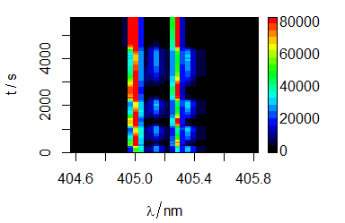

Figure 6.2: Spectra matrix with time (in column `t`) on y axis.

```r
plotmat(laser, y = "t")
```

Alternatively, y values and axis label can be given separately.

```r
plotmat(laser, y = laser$t, ylab = labels(laser, "t"))
```

## 6.3 Contour Lines

Contour lines may also be added (Fig. 6.3).

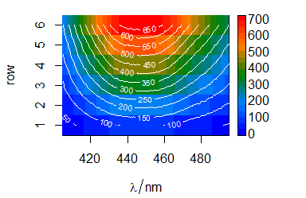

Figure 6.3: Spectra matrix with added contour lines.

```r
plotmat(flu, col = matlab.dark.palette(20))
plotmat(flu, col = "white", contour = TRUE, add = TRUE)
```

## 6.4 Colour-Coded Points: Special Panel Function

In `levelplot()`, colour-coded points may be set via special panel function (Fig. 6.4).

```r
library("latticeExtra")

barb <- do.call(collapse, barbiturates[1:50])
barb <- orderwl(barb)
```

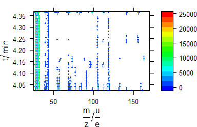

Figure 6.4: Colour-coded points via special panel function.

```r
levelplot(spc ~ .wavelength * z, barb,
  panel = panel.levelplot.points,
  cex = .33, col.symbol = NA,
  col.regions = matlab.palette
)
```

# 7 False-Colour Maps: `plotmap()`

## 7.1 Plotting map

```r
plotmap(chondro)
```

[output not shown]

## 7.2 Plotting Maps with Manually Specified X and Y Axes

Specify the colour-coded variable, abscissa and ordinate as formula: `colour.coded ~ abscissa * ordinate` (Fig. 7.2).

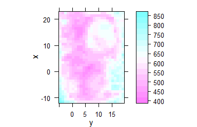

Figure 7.2: False colour map with an explicit specification of x and y axes.

```r
plotmap(chondro, spc ~ y * x)
```

## 7.3 Discrete Colours

Factor variables may be used for discrete colour coding (Fig. 7.3).

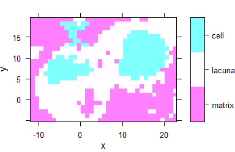

Figure 7.3: False colour map with colours defined by a factor variable.

```r
plotmap(chondro, clusters ~ x * y)
```

If the colour-coded variable is a factor, each level gets its own colour, and the legend is labelled accordingly.

## 7.4 Different Palette

To use a different palette, use argument `col.regions` (Fig. 7.4).

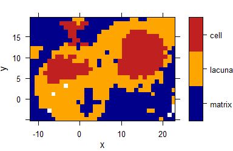

Figure 7.4: False colour map with non-default colour palette.

```r
plotmap(chondro, clusters ~ x * y,
  col.regions = cluster.cols
)
```

# 8 Fine-Tuning *lattice* Parameters

The plotting of colour maps is done via R package **lattice** (aka Trellis graphic approach), which is highly customizable. Use function `trellis.par.get()` and `trellis.par.set()` to get/set the settings for the current graphics device.

```r
my.theme <- trellis.par.get()
names(my.theme) # note how many parameters are tunable
```

```
#>  [1] "grid.pars"         "fontsize"          "background"        "panel.background"
#>  [5] "clip"              "add.line"          "add.text"          "plot.polygon"
#>  [9] "box.dot"           "box.rectangle"     "box.umbrella"      "dot.line"
#> [13] "dot.symbol"        "plot.line"         "plot.symbol"       "reference.line"
#> [17] "strip.background"  "strip.shingle"     "strip.border"      "superpose.line"
#> [21] "superpose.symbol"  "superpose.polygon" "regions"           "shade.colors"
#> [25] "axis.line"         "axis.text"         "axis.components"   "layout.heights"
#> [29] "layout.widths"     "box.3d"            "par.xlab.text"     "par.ylab.text"
#> [33] "par.zlab.text"     "par.main.text"     "par.sub.text"
```

Any of these parameters can be fine-tuned to produce the desired output. For example, parameter `my.theme$region` is responsible for the appearance of color maps, and it contains elements `$alpha` and `$col`. By changing these parameters you can create your own theme for plotting and pass it to the plotting function via `par.settings`.

## 8.1 Changed Palette

Fig. 8.1 uses a customized **lattice** theme.

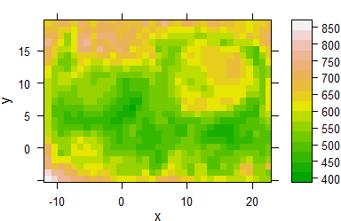

Figure 8.1: A false-colour map that uses `terrain.colors` palette.

```r
my.theme$regions$col <- grDevices::terrain.colors
plotmap(chondro, par.settings = my.theme)
```

It is possible to **persistently** (i.e. inside of the current R session) set **lattice** parameters, so they would apply to all further plots. This is done via a call to `trellis.par.set()`, for example `trellis.par.set(my.theme)`.

The current settings can be visualized via a call to `show.settings()`

## 8.2 Show Current *lattice* Settings

Graphical parameters for *trellis* may be displayed via `show.settings()` (Fig. 8.2).

```r
# Display current trellis parameters
show.settings()
```

```r
show.settings(my.theme)
```

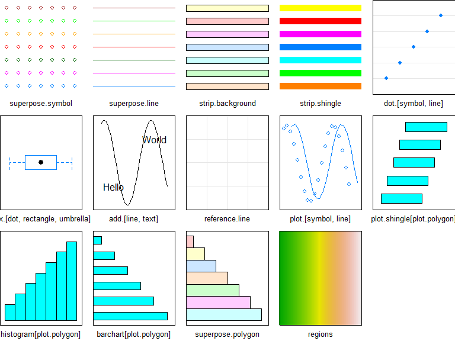

Figure 8.2: Show *lattice** settings.

An overview of different colour palettes, and ways to create your own, can be found in the [R colour cheatsheet](https://www.nceas.ucsb.edu/~frazier/RSpatialGuides/colorPaletteCheatsheet.pdf).

## 8.3 Defined Wavelengths

A map of the average intensity at particular wavelengths can be plotted if the wavelengths of interested are explicitly extracted (Fig. 8.3).

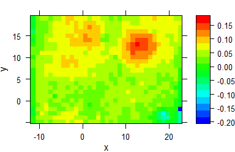

Figure 8.3: A map of average intensity at explicitly indicated wavelengths.

```r
plotmap(chondro.preproc[, , c(
   728,  782, 1098,
  1240, 1482, 1577
)],
  col.regions = matlab.palette
)
```

## 8.4 Conditioning

Logical conditions may be used to create subplots (Fig. 8.4).

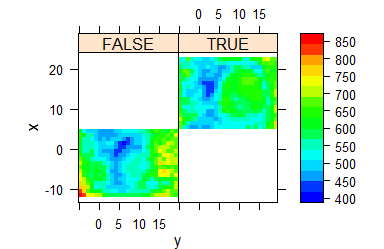

Figure 8.4: Subplots created by logical conditions.

```r
plotmap(chondro,
  spc ~ y * x | x > 5,
  col.regions = matlab.palette(20)
)
```

## 8.5 Conditioning on `.wavelength`

Function `plotmap()` automatically applies the function in `func` before plotting. Argument `func` defaults to function `mean()`. In order to suppress this, use `func = NULL`. This allows conditioning on the wavelengths.

Fig. 8.5 demonstrates an example to plot the maps of principal components scores.

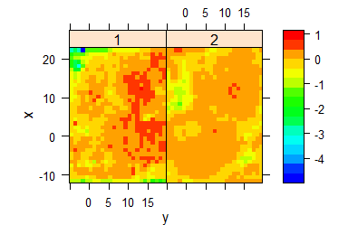

Figure 8.5: The maps of the scores of the first two principal components (I).

```r
pca <- prcomp(~spc, data = chondro.preproc$.)

scores <- decomposition(chondro, pca$x,
  label.wavelength = "PC",
  label.spc = "score /  a.u."
)

plotmap(scores[, , 1:2],
  spc ~ y * x | as.factor(.wavelength),
  func = NULL,
  col.regions = matlab.palette(20)
)
```

Alternatively, use `levelplot()` directly (Fig. 8.6).

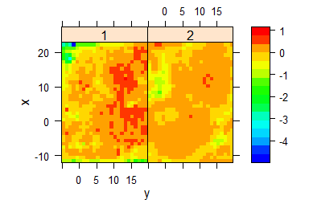

Figure 8.6: The maps of the scores of the first two principal components (II).

```r
levelplot(spc ~ y * x | as.factor(.wavelength),
  scores[, , 1:2],
  aspect = "iso",
  col.regions = matlab.palette(20)
)
```

## 8.6 Voronoi Plot

Fig. 8.7 shows an example of a Voronoi plot. Voronoi uses `panel.voronoi()` from package **latticeExtra**[3]. The tesselation is calculated by default using package **deldir**[4], but package **tripack**[5] can also be used. Package **tripack** seems to be faster in general, but may “hang” with certain data sets (particularly regular grids with missing spectra as in this example). Furthermore, it is not FOSS (free and open-source software), so users are kindly asked to review package **tripack**’s license before using it.

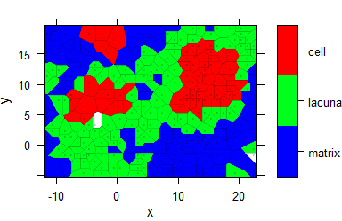

Figure 8.7: Voronoi plot that uses non-default discrette colour palette.

```r
plotvoronoi(sample(chondro, 300), clusters ~ x * y,
  col.regions = matlab.palette(20)
)
```

## 8.7 Mark Missing Spectra

If the spectra come from a rectangular grid, missing positions can be marked with the following panel function:

```r
mark.missing <- function(x, y, z, ...) {
  panel.levelplot(x, y, z, ...)

  miss <- expand.grid(x = unique(x), y = unique(y))
  miss <- merge(miss, data.frame(x, y, TRUE), all.x = TRUE)
  miss <- miss[is.na(miss[, 3]), ]
  panel.xyplot(miss[, 1], miss[, 2], pch = 4, ...)
}
```

Fig. 8.8 shows the result.

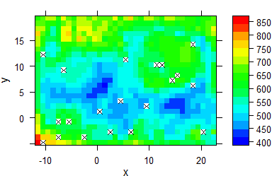

Figure 8.8: Marks of missing spectra in a false-colour map.

```r
plotmap(sample(chondro, length(chondro) - 20),
  col.regions = matlab.palette(20),
  col = "black",
  panel = mark.missing
)
```

## 8.8 Unevenly Spaced Measurement Grid

The panel function used by `plotmap()` defaults to `panel.levelplot.raster()` which assumes an evenly spaced measurement grid. Even if the spectra are measured on a nominally evenly spaced grid, the actual stage position may slightly vary due to positioning inaccuracy and some manufacturers (e.g., Kaiser) record the position reported by the stage rather than the position requested by the stage control. This leads to weird-looking output with holes, and possibly wrong columns (Fig. 8.9).

```
#> Warning in (function (x, y, z, subscripts, at = pretty(z), ..., col.regions = regions$col, : 'x'
#> values are not equispaced; output may be wrong
#> Warning in (function (x, y, z, subscripts, at = pretty(z), ..., col.regions = regions$col, : 'y'
#> values are not equispaced; output may be wrong
```

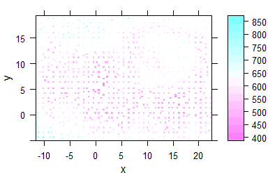

Figure 8.9: Unevenly spaced measurement grid: example I. Note warnings `values are not equispaced; output may be wrong`.

```r
plotmap(uneven)
```

The symptom of this situation are warnings about values in x and/or y not being equispaced; and that the output, therefore, may be wrong.

One possibility to obtain a correct map is using `plotvoronoi()` instead which will construct a mosaic-like image with the respective “pixel” areas being centred around the actually recorded `$x` and `$y` position (Fig. 8.10).

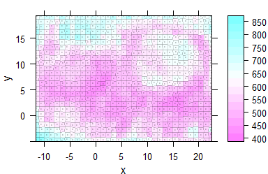

Figure 8.10: Unevenly spaced measurement grid: example II.

```r
plotvoronoi(uneven)
```

Another possibility that underlines a point shape of the measurements is switching to `latticeExtra::panel.levelplot.points()` (Fig. 8.11).

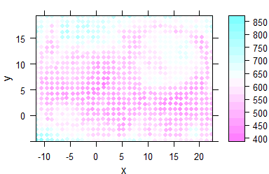

Figure 8.11: Unevenly spaced measurement grid: example III.

```r
plotmap(uneven,
  panel = panel.levelplot.points,
  cex = 0.75,
  col.symbol = NA
)
```

Alternatively, the measurement raster positions can be rounded to their nominal raster (e.g. Fig. 8.12).

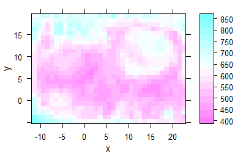

Figure 8.12: Unevenly spaced measurement grid: example IV.

```r
rx <- makeraster(uneven$x, startx = -11.55, d = 1, tol = 0.3)
uneven$x <- rx$x

ry <- makeraster(uneven$y, startx = -4.77, d = 1, tol = 0.3)
uneven$y <- ry$x

plotmap(uneven)
```

# 9 3D Plots (with package *rgl*)

Package **rgl**[6] offers fast 3d plotting in R. As package **rgl**’s axis annotations are sometimes awkward, they may better be set manually:

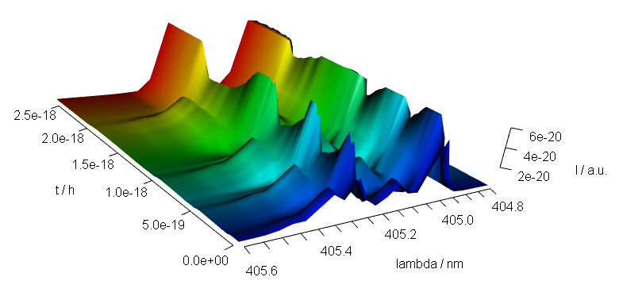

Figure 9.1: A snapshot of an **rgl** plot.

```r
library(rgl)

laser <- laser [, , 404.8 ~ 405.6] / 10000
laser$t <- laser$t / 3600
cols <- rep(matlab.palette(nrow(laser)), nwl(laser))
surface3d(
  y = wl(laser), x = laser$t,
  z = laser$spc, col = cols
)
aspect3d(c(1, 1, 0.25))
axes3d(c("x+-", "y--", "z--"))
axes3d("y--", nticks = 25, labels = FALSE)
mtext3d("t / h", "x+-", line = 2.5)
mtext3d("lambda / nm", "y--", line = 2.5)
mtext3d("I / a.u.", edge = "z--", line = 2.5)
```